# Chicago Crimes

### Residual Plotting of the models

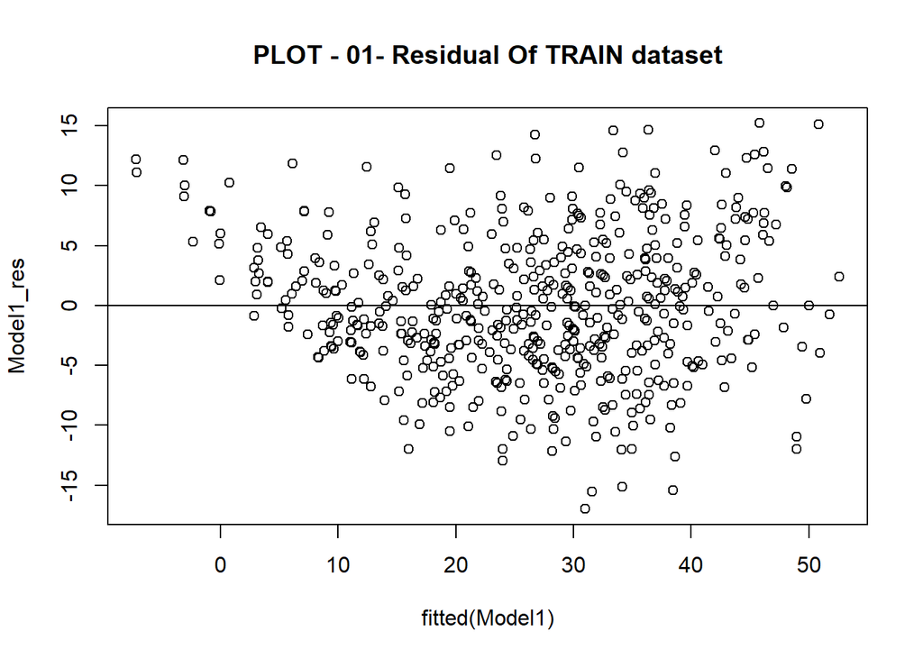

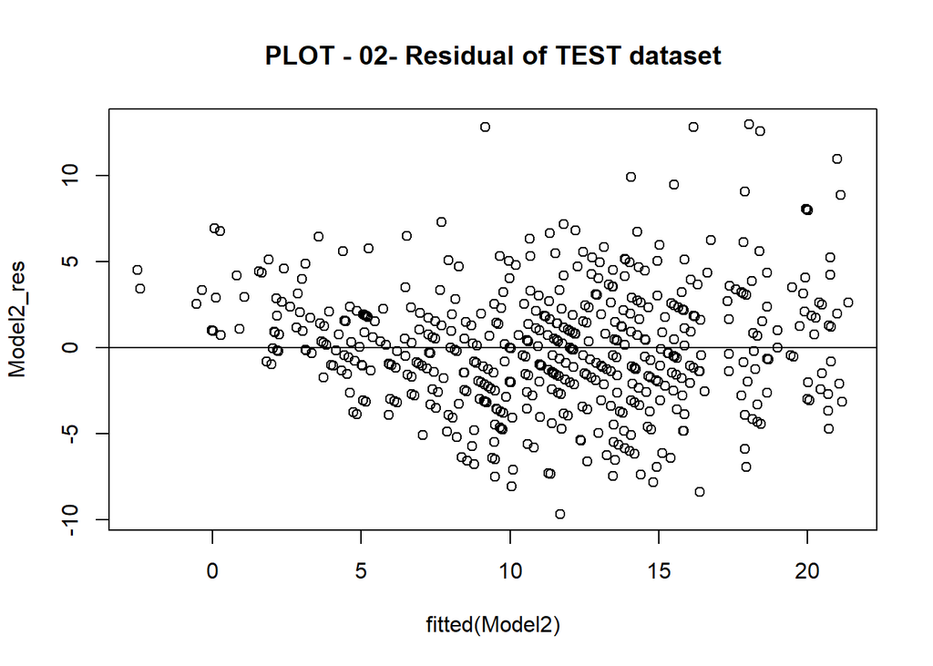

```r
Model1_res <- resid(Model1)
Model2_res <- resid(Model2)

plot(fitted(Model1), Model1_res) +
  abline(0,0)+
  title("PLOT - 01- Residual Of TRAIN dataset")

plot(fitted(Model2), Model2_res) +
  abline(0,0)+
  title("PLOT - 02- Residual of TEST dataset")
```

- The response variable for this model was Crime rate and the predictor variables were District and Time
- observations are evenly distributed

### Q-Q PLOT

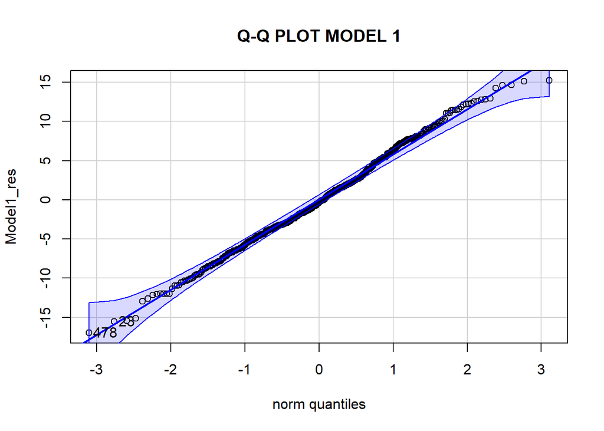

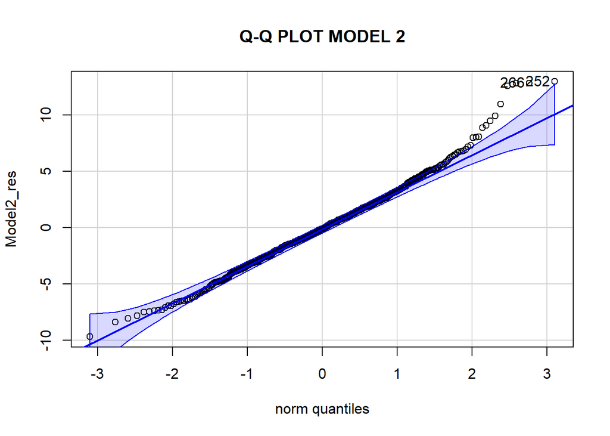

```r
qqPlot(Model1_res)+
  title("Q-Q PLOT MODEL 1")

qqPlot(Model2_res)+
  title("Q-Q PLOT MODEL 2")
```

From plot of model 1 and model 2 we can wee that most of the observation follow the normal line and there are less outliers

### MULTI COLLINEARITY

```r
## model 1
vif(Model1)
```

```
                          GVIF Df GVIF^(1/(2*Df))
  Time                1.001898 23        1.000041
  as.factor(District) 1.001898 21        1.000045
```

```r
## model 2
vif(Model2)
```

```
                          GVIF Df GVIF^(1/(2*Df))
  Time                1.003807 23        1.000083
  as.factor(District) 1.003807 21        1.000090
```

Multicollinearity help us to know if the predictor variables (independent) have correlation or not. If the value is below 5 we can say that there is not correlation between the Predictor variables.